# Lab 7

Author

Nicholas Le

```python
import pandas as pd
myHeart= pd.read_csv("https://www.dropbox.com/s/aohbr6yb9ifmc8w/heart_attack.csv?dl=1")
myHeart
```

|  | age | sex | cp | trtbps | chol | restecg | thalach | output |
| --- | --- | --- | --- | --- | --- | --- | --- | --- |
| 0 | 63 | 1 | 3 | 145 | 233 | 0 | 150 | 1 |
| 1 | 37 | 1 | 2 | 130 | 250 | 1 | 187 | 1 |
| 2 | 56 | 1 | 1 | 120 | 236 | 1 | 178 | 1 |
| 3 | 57 | 0 | 0 | 120 | 354 | 1 | 163 | 1 |
| 4 | 57 | 1 | 0 | 140 | 192 | 1 | 148 | 1 |
| ... | ... | ... | ... | ... | ... | ... | ... | ... |
| 268 | 59 | 1 | 0 | 164 | 176 | 0 | 90 | 0 |
| 269 | 57 | 0 | 0 | 140 | 241 | 1 | 123 | 0 |
| 270 | 45 | 1 | 3 | 110 | 264 | 1 | 132 | 0 |
| 271 | 68 | 1 | 0 | 144 | 193 | 1 | 141 | 0 |
| 272 | 57 | 0 | 1 | 130 | 236 | 0 | 174 | 0 |

273 rows × 8 columns

```python
import numpy as np
from plotnine import *

from sklearn.model_selection import StratifiedKFold, GridSearchCV, cross_val_predict, cross_val_score,  train_test_split
from sklearn.preprocessing import StandardScaler
from sklearn.pipeline import Pipeline
from sklearn.neighbors import KNeighborsClassifier
from sklearn.linear_model import LogisticRegression
from sklearn.tree import DecisionTreeClassifier
from sklearn.metrics import ConfusionMatrixDisplay,recall_score,confusion_matrix,roc_auc_score,  precision_score,roc_curve
```

```python
myHeart.isna().sum()
myHeart = myHeart.dropna()
x = myHeart.drop(columns=["output"])
y = myHeart["output"]
```

```python
x_train, x_test, y_train, y_test =train_test_split(x,y, test_size=0.2, random_state=42, stratify=y)
cv = StratifiedKFold(n_splits = 5, shuffle = True, random_state=42)
```

```python
def model_test (model, model_name):
    model.fit(x_train, y_train)
    y_test_predict = model.predict(x_test)
    y_test_prob=model.predict_proba(x_test)[:,1]
    cm = confusion_matrix(y_test,y_test_predict)
    auc = roc_auc_score(y_test, y_test_prob)

    print(f"{model_name}: ")
    print("Test ROC AUC: ", {auc})
    print("Test Confusion Matrix: ")
    print(cm)
    return y_test_prob
```

Part One: Fitting Models Q1: KNN

```python
k_range = list(range(1,20))
k_result = []

for k in k_range:
    pipe = Pipeline([
        ("scaler", StandardScaler()),
        ("knn",KNeighborsClassifier(n_neighbors = k))
    ])
    cv_auc = cross_val_score(pipe, x_train, y_train, scoring="roc_auc",cv=5).mean()
    k_result.append((k,cv_auc))
k_result


best_k, best_auc = max(k_result, key=lambda x:x[1])

print("Best K:",best_k)
print("Best AUC:",best_auc)

knn_pipe = Pipeline([
    ("scaler", StandardScaler()),
    ("knn", KNeighborsClassifier(n_neighbors=best_k))
])

knn_final_probability = model_test(knn_pipe, "knn")
```

```
Best K: 14
Best AUC: 0.8719629917184266
knn:
Test ROC AUC:  {0.7068965517241379}
Test Confusion Matrix:
[[16 10]
 [10 19]]
```

Q2: Logistic Regression

```python
c_range =[0.001,0.01, 0.1,1,10,100]
log_result=[]

for c in c_range:
    pipe = Pipeline([
        ("scaler", StandardScaler()),
        ("logreg",LogisticRegression(C=c, max_iter=10000))
    ])
    cv_auc = cross_val_score(pipe, x_train, y_train, scoring="roc_auc",cv=5).mean()
    log_result.append((c,cv_auc))
log_result

best_c, best_log_auc = max(log_result, key=lambda x:x[1])


print("Best C:",best_c)
print("Best AUC:",best_log_auc)

lr_pipe = Pipeline([
    ("scaler", StandardScaler()),
    ("logreg",LogisticRegression(C=best_c, max_iter=10000))
])

logr_final_probability = model_test(lr_pipe, "logistic regression")
```

```
Best C: 0.01
Best AUC: 0.8645005175983437
logistic regression:
Test ROC AUC:  {0.7957559681697612}
Test Confusion Matrix:
[[16 10]
 [ 4 25]]
```

Testing the values for c between 0.001 - 100, I found that the best c value was 0.01, which had a CV AUC of 0.8645, which shows a strong and stable peformance during training. After the final model, the test ROC AUC was 0.79576, which is closer to the actual value of the CV AUC than the KNN model.

Q3: Decision Tree

```python
depth_range =[2,3,4, 5,6,7,8,9,10]
dtree_result=[]

for d in depth_range:
    pipe = Pipeline([
        ("d_tree", DecisionTreeClassifier(max_depth=d, random_state =42))
    ])
    cv_auc = cross_val_score(pipe, x_train, y_train, scoring="roc_auc",cv=5).mean()
    dtree_result.append((d,cv_auc))
log_result

best_depth, best_tree_auc = max(dtree_result, key=lambda x:x[1])


print("Best C:",best_depth)
print("Best AUC:",best_tree_auc)

dtree_pipe = Pipeline([
    ("d_tree", DecisionTreeClassifier(max_depth=best_depth, random_state =42))
])

dtree_final_probability = model_test(dtree_pipe, "decision tree")
```

```
Best C: 4
Best AUC: 0.7802717391304348
decision tree:
Test ROC AUC:  {0.7141909814323608}
Test Confusion Matrix:
[[18  8]
 [ 8 21]]
```

Q4: Interpretation

```python
log_coef= lr_pipe.named_steps["logreg"].coef_[0]

log_coef_table =pd.DataFrame({
    "feature": x.columns,
    "coefficient": log_coef,
    "absolute_coefficient": np.abs(log_coef)
}).sort_values("absolute_coefficient",ascending=False)

log_coef_table
```

|  | feature | coefficient | absolute_coefficient |
| --- | --- | --- | --- |
| 6 | thalach | 0.281641 | 0.281641 |
| 2 | cp | 0.250365 | 0.250365 |
| 1 | sex | -0.221231 | 0.221231 |
| 0 | age | -0.129660 | 0.129660 |
| 5 | restecg | 0.094455 | 0.094455 |
| 3 | trtbps | -0.061967 | 0.061967 |
| 4 | chol | -0.023530 | 0.023530 |

The most important predictors for the Logistic Regression model, was thalach and cp, as both had strong positive coefficients, which means that these factors better predict someone who might be at high risk of an attack. Sex and age also play as moderate predictors.

```python
dtree_importance= dtree_pipe.named_steps["d_tree"].feature_importances_

dt_importance_table =pd.DataFrame({
    "feature": x.columns,
    "importance": dtree_importance
}).sort_values("importance",ascending=False)

dt_importance_table
```

|  | feature | importance |
| --- | --- | --- |
| 2 | cp | 0.446129 |
| 6 | thalach | 0.171669 |
| 0 | age | 0.123938 |
| 1 | sex | 0.117217 |
| 3 | trtbps | 0.109069 |
| 4 | chol | 0.031979 |
| 5 | restecg | 0.000000 |

The most important varaible. for the Decision Tree model were cp, which a value of 0.446, this means that the model used that variable most when making splits. Additionally Thalach and age also were important to the model as well.

Q5: ROC Curve

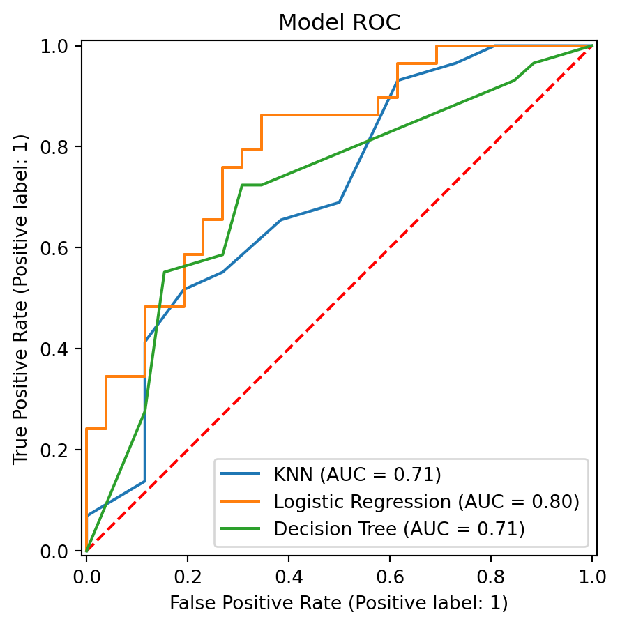

```python
from sklearn.metrics import RocCurveDisplay
import matplotlib.pyplot as plt
fig,ax=plt.subplots(figsize=(5,5))
ax.plot([0,1],[0,1],"--",color="red")

RocCurveDisplay.from_estimator(knn_pipe, x_test, y_test, ax=ax,name="KNN")
RocCurveDisplay.from_estimator(lr_pipe, x_test, y_test, ax=ax, name= "Logistic Regression")
RocCurveDisplay.from_estimator(dtree_pipe, x_test, y_test, ax=ax,name= "Decision Tree")

plt.title("Model ROC")
plt.show()
```

Part Two: Metrics KNN Metrics

```python
from sklearn.metrics import make_scorer, recall_score, precision_score

recall_scoring = make_scorer(recall_score, pos_label=1)
precision_scoring  = make_scorer(precision_score, pos_label=1)
specificity_scoring  = make_scorer(recall_score, pos_label=0)

def computation(model, model_name):
    recall= cross_val_score(model, x_train,y_train, cv=cv, scoring=recall_scoring).mean()
    precision =cross_val_score(model, x_train, y_train, cv=cv, scoring=precision_scoring).mean()
    specificity=cross_val_score(model,x_train, y_train, cv=cv,scoring=specificity_scoring).mean()

    print(f"{model_name}: ")
    print(f"Recall: ",recall)
    print(f"Precision: ",precision)
    print(f"Specificity: ",specificity)
    print("")

computation(knn_pipe,"knn")
computation(lr_pipe,"logistic regression")
computation(dtree_pipe,"decision tree")
```

```
knn:
Recall:  0.8286231884057971
Precision:  0.7654558404558405
Specificity:  0.7033333333333334

logistic regression:
Recall:  0.9144927536231885
Precision:  0.7448867942402425
Specificity:  0.6342857142857142

decision tree:
Recall:  0.7427536231884058
Precision:  0.7639496064576157
Specificity:  0.7338095238095238
```

The Logistic Regression model best showed recall/sensitivity with a value of 0.914, meaning that it would correctly identify the largest proportion of real high risk paitents.

The KNN model best showed precision with a value of 0.7655, meanin that what it identifies patients as high risk, it is more correct than other models.

The Decision Tree model best showed specificity with a value of 0.7338, meaning it was the most accurate in identifying patients who are not at risk.

Part Three: Discussion Q1: I would use Recall/Sensitivity, as missing high-risk patients would be more a serious matter for the hospital. I would use a logistic regression model, as the recall value was 0.914, which means it is the most true when identifying high risk cases. I would expect to achieve about 0.914 recall on patients in the future.

Q2: I would use Precision, as admitting low-risk patients by mistake would leave high-risk patients unable to be treated due to lack of space. I would use a KNN model, as it has the highest precision amongst the other models. It has a precision value of 0.765, which means its more accurate when predicing the true high-risk patients. I would expect to have about a 0.765 precision for patients in the future.

Q3: I would use a Logistic Regression Model as it clearly shows the variables and its coefficients to show which factors are the most impactful with high-risk patients. I would expect to have a 0.80 ROC AUC on future patients observations.

Q4: To compare the diagnoses from the newer doctors for patients, I would use the Logistic Regression Model. As seen in the ROC Curves graph, the Logistic Regression model shows the best overall trend. This means that it has the best AUC.

Part Four: Validation

```python
myHeartVal = pd.read_csv("https://www.dropbox.com/s/jkwqdiyx6o6oad0/heart_attack_validation.csv?dl=1")
x_val = myHeartVal.drop(columns=["output"])
y_val = myHeartVal["output"]

def model_validation (model, model_name):
    predict = model.predict(x_val)
    probability = model.predict_proba(x_val)[:,1]
    cm = confusion_matrix(y_val,predict)
    auc = roc_auc_score(y_val, probability)
    precision= precision_score(y_val,predict)
    recall= recall_score(y_val,predict)

    print(f"{model_name}: ")
    print("Test ROC AUC: ", {auc})
    print("Test Confusion Matrix: ")
    print(cm)
    print("Precision: ",precision)
    print("Recall: ",recall)
    print("======================================")


model_validation(knn_pipe, "knn")
model_validation(lr_pipe, "logistic regression")
model_validation(dtree_pipe, "decision tree")
```

```
knn:
Test ROC AUC:  {0.9401913875598086}
Test Confusion Matrix:
[[10  1]
 [ 7 12]]
Precision:  0.9230769230769231
Recall:  0.631578947368421
======================================
logistic regression:
Test ROC AUC:  {0.9234449760765551}
Test Confusion Matrix:
[[ 9  2]
 [ 4 15]]
Precision:  0.8823529411764706
Recall:  0.7894736842105263
======================================
decision tree:
Test ROC AUC:  {0.799043062200957}
Test Confusion Matrix:
[[10  1]
 [ 5 14]]
Precision:  0.9333333333333333
Recall:  0.7368421052631579
======================================
```

KNN: For KNN, its ROC AUC was 0.940, showing the model to have the highest validation. It has a precision of 0.923, but a recall of 0.632. This shows that the model continues to miss more high-risk patients than desired.

Logistic Regression: For Logistic Regression, its ROC AUC was 0.9234 and a recall of 0.789. This shows that the model seems to be balanced and generally stable compared to other models.

Decision Tree: For Decision Tree, its ROC AUC was 0.7990, the precision is 0.933, and the recall was 0.737, which was similar to Part 1.

Overall, Logistic Regression seems to be the most consistent.

Part Five: Cohen’s Kappa

```python
from sklearn.metrics import cohen_kappa_score

knn_preds  = knn_pipe.predict(x_val)
lr_preds   = lr_pipe.predict(x_val)
dtree_preds = dtree_pipe.predict(x_val)

kappa_knn  = cohen_kappa_score(y_val, knn_preds)
kappa_lr   = cohen_kappa_score(y_val, lr_preds)
kappa_dtree = cohen_kappa_score(y_val, dtree_preds)

print("KNN Kappa: ",kappa_knn)
print("======================================")
print("Logistic Regression Kappa: ",kappa_lr)
print("======================================")
print("Decision Tree Kappa: ",kappa_dtree)
print("======================================")
```

```
KNN Kappa:  0.4849785407725322
======================================
Logistic Regression Kappa:  0.5852534562211982
======================================
Decision Tree Kappa:  0.6
======================================
```

Cohen’s Kappa seems useful when one class is more common than the other classes, meaning when the classes are imbalanced. My results from Kappa show 0.485 (KNN), 0.585 (Logistic Regression), and 0.6 (Decision Tree). Although the values show a differences, it does not change my conclusion that logistic regression is the most reliable, since its more consistent and stable as shown with its high ROC AUC.